# prey_capture_Gasteracantha

Fabian C. Salgado-Roa

22/19/2023

# Introduction

## Load the libraries and standard error function

```r
library(tidyverse)
library(glmmTMB)
library(car)
library(DHARMa)
```

Standard error function

```r
se <- function(x) sd(x)/sqrt(length(x))
```

## Load the datasets

Total dataset

```r
tmp_noNA<-read_csv("data_gasteracantha.csv",col_names=T)
```

Treat time as a categorical variable

```r
tmp_noNA$Time<-as.character(tmp_noNA$Time)
```

Let’s create subset excluding the empty web observations. This will facilitate the comparisons between colour morphs

```r
tmp_ind<-tmp_noNA %>% filter(colour!="empty")
```

Because the measures are repeated for each individual, lets create a subset with a single observation to explore association between colour morph and the variables measured

```r
unique_ind <- tmp_noNA %>% distinct(code, .keep_all=T)
unique_noEmpty<-unique_ind %>% filter(colour!="empty")
```

# Association between the predictors

Check the normality of the variables per colour category (including empty web when possible)

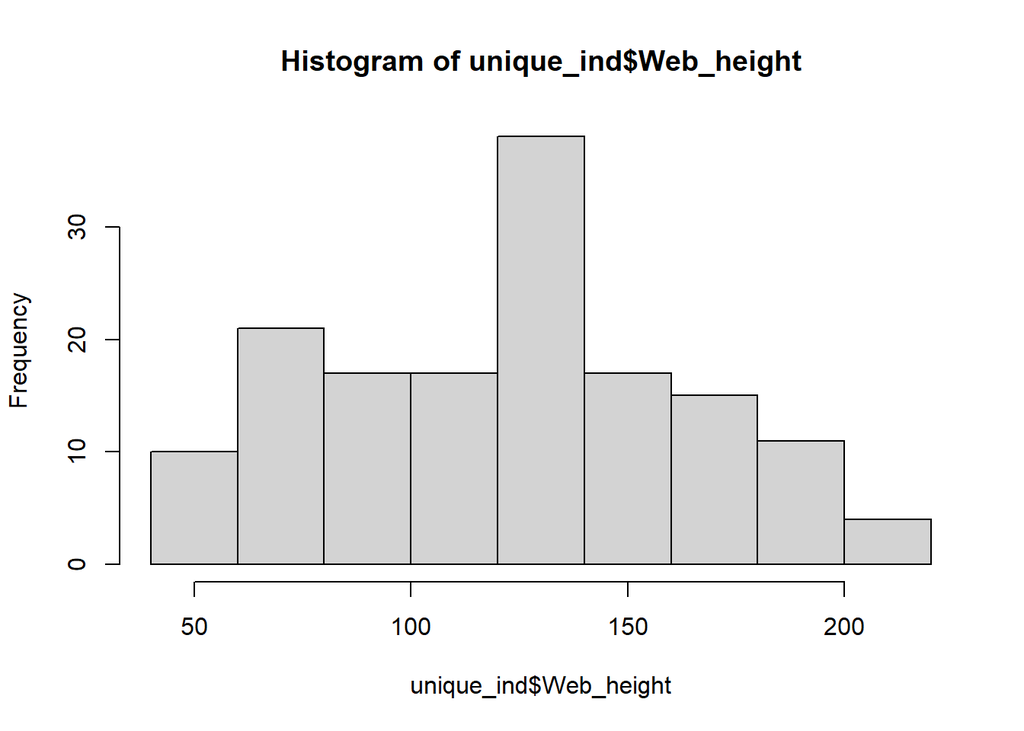

```r
#Web height
hist(unique_ind$Web_height)
```

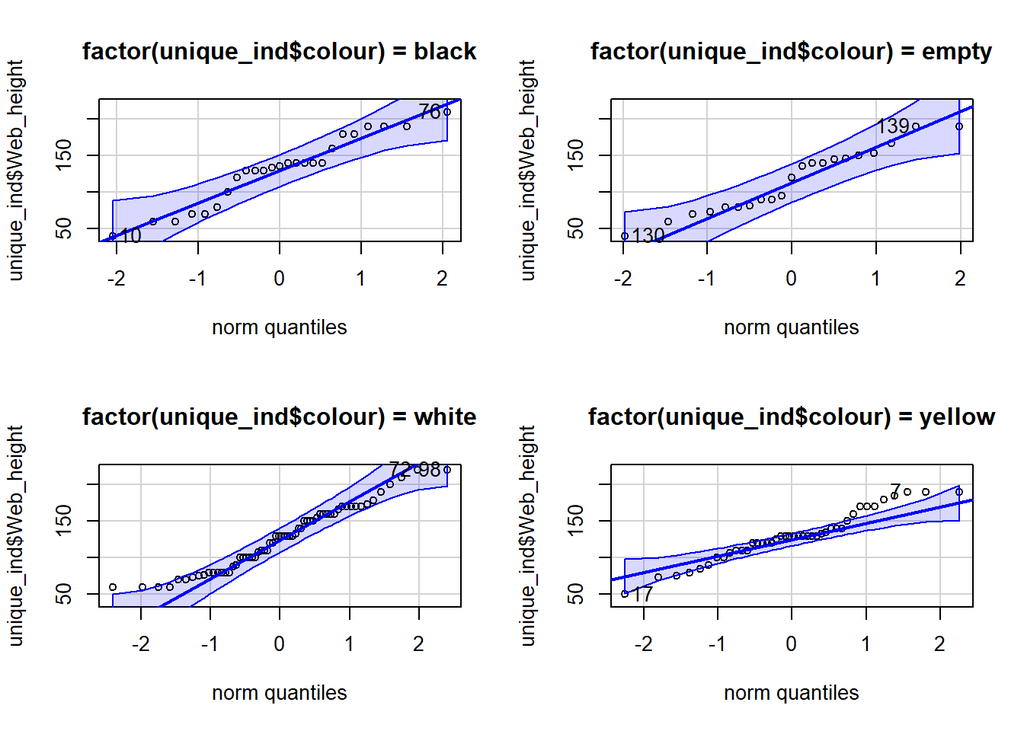

```r
qqPlot(unique_ind$Web_height,groups=factor(unique_ind$colour))
```

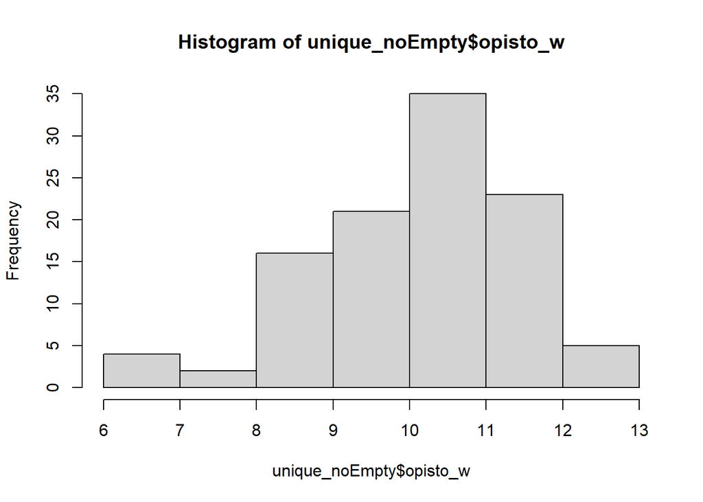

```r
#opisthosoma width
hist(unique_noEmpty$opisto_w)
```

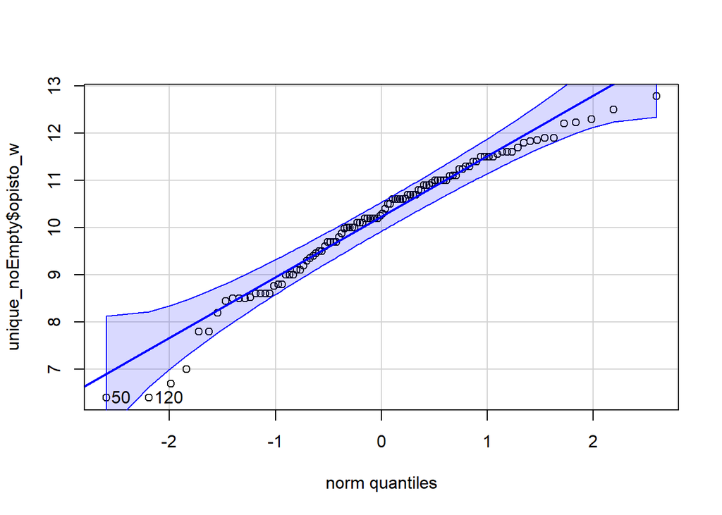

```r
qqPlot(unique_noEmpty$opisto_w)
```

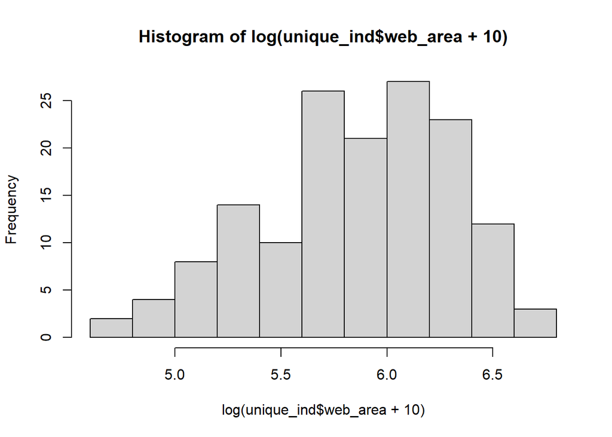

```r
#web Area
hist(log(unique_ind$web_area+10))
```

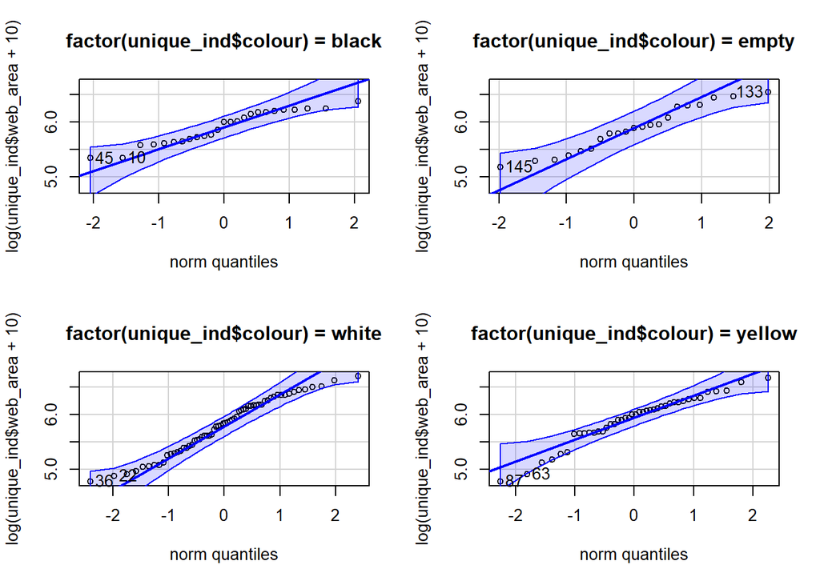

```r
qqPlot(log(unique_ind$web_area+10),groups=factor(unique_ind$colour))
```

It seems that all the variables are following a normal distribution in every colour category

# Linear models

**Web height**

Run the linear model

```r
mod_webHeight<-lm(Web_height~colour,data=unique_ind)
#plot(mod_webHeight)
```

Check the significance of the predictor

```r
summary(mod_webHeight)
```

```
##
## Call:
## lm(formula = Web_height ~ colour, data = unique_ind)
##
## Residuals:
##     Min      1Q  Median      3Q     Max
## -90.400 -29.238   0.762  30.560  93.790
##
## Coefficients:
##              Estimate Std. Error t value Pr(>|t|)
## (Intercept)   130.400      8.241  15.824   <2e-16 ***
## colourempty   -14.352     12.197  -1.177    0.241
## colourwhite    -4.190      9.762  -0.429    0.668
## colouryellow   -1.162     10.408  -0.112    0.911
## ---
## Signif. codes:  0 '***' 0.001 '**' 0.01 '*' 0.05 '.' 0.1 ' ' 1
##
## Residual standard error: 41.2 on 146 degrees of freedom
## Multiple R-squared:  0.01192,    Adjusted R-squared:  -0.008382
## F-statistic: 0.5871 on 3 and 146 DF,  p-value: 0.6244
```

```r
anova(mod_webHeight)
```

```
## Analysis of Variance Table
##
## Response: Web_height
##            Df Sum Sq Mean Sq F value Pr(>F)
## colour      3   2990  996.83  0.5871 0.6244
## Residuals 146 247871 1697.75
```

**Opisthosoma width**

Run the linear model

```r
mod_opistoW<-lm(opisto_w~colour,data=unique_noEmpty)
#plot(mod_opistoW)
```

Check the significance of the predictor

```r
summary(mod_opistoW)
```

```
##
## Call:
## lm(formula = opisto_w ~ colour, data = unique_noEmpty)
##
## Residuals:
##     Min      1Q  Median      3Q     Max
## -3.2229 -0.8017  0.0826  0.8767  2.2771
##
## Coefficients:
##              Estimate Std. Error t value Pr(>|t|)
## (Intercept)    9.6229     0.2640  36.444   <2e-16 ***
## colourwhite    0.5916     0.3245   1.823   0.0712 .
## colouryellow   0.8945     0.3428   2.609   0.0104 *
## ---
## Signif. codes:  0 '***' 0.001 '**' 0.01 '*' 0.05 '.' 0.1 ' ' 1
##
## Residual standard error: 1.294 on 103 degrees of freedom
##   (23 observations deleted due to missingness)
## Multiple R-squared:  0.0625, Adjusted R-squared:  0.04429
## F-statistic: 3.433 on 2 and 103 DF,  p-value: 0.03603
```

```r
anova(mod_opistoW)
```

```
## Analysis of Variance Table
##
## Response: opisto_w
##            Df  Sum Sq Mean Sq F value  Pr(>F)
## colour      2  11.489  5.7445  3.4331 0.03603 *
## Residuals 103 172.350  1.6733
## ---
## Signif. codes:  0 '***' 0.001 '**' 0.01 '*' 0.05 '.' 0.1 ' ' 1
```

*Opisthosoma width seems to differ between colour morphs*

**Web area**

Run the linear model

```r
mod_webArea<-lm(sqrt(web_area+10)~colour,data=unique_ind)
```

Check the assumptions of the linear model

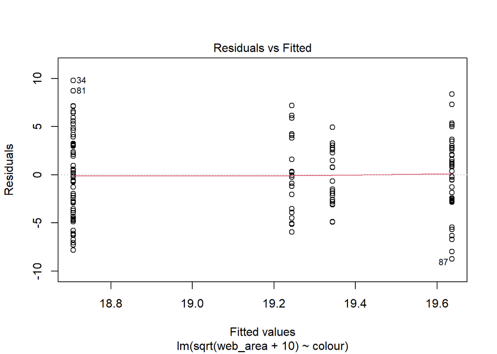

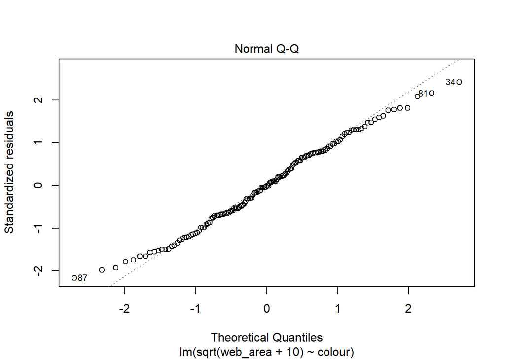

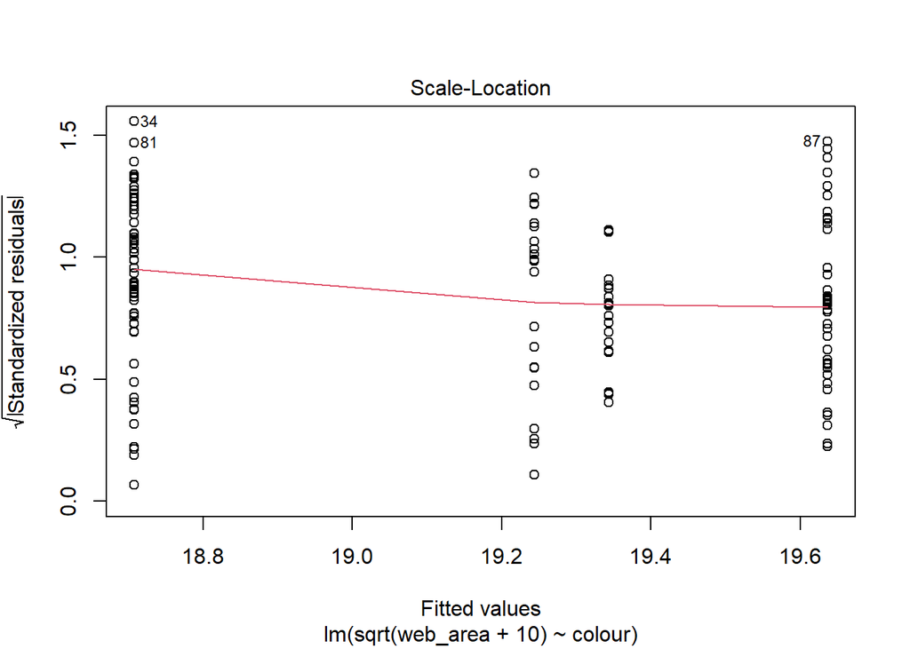

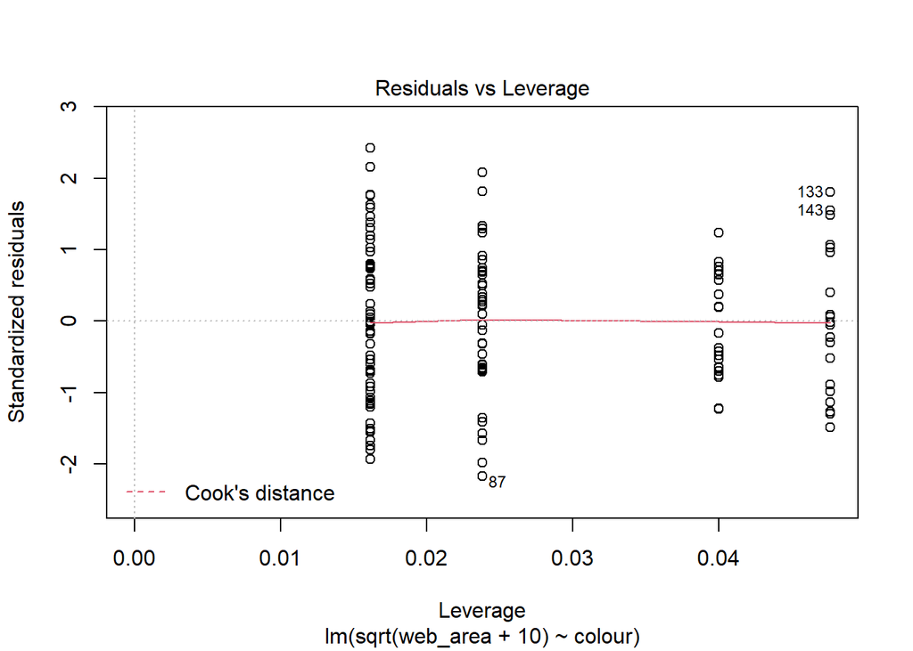

```r
plot(mod_webArea)
```

```r
shapiro.test(mod_webArea$residuals)
```

```
##
##  Shapiro-Wilk normality test
##
## data:  mod_webArea$residuals
## W = 0.98884, p-value = 0.2767
```

*everything seems ok*

Check the significance of the predictor

```r
summary(mod_webArea)
```

```
##
## Call:
## lm(formula = sqrt(web_area + 10) ~ colour, data = unique_ind)
##
## Residuals:
##    Min     1Q Median     3Q    Max
## -8.756 -2.785 -0.096  3.053  9.800
##
## Coefficients:
##              Estimate Std. Error t value Pr(>|t|)
## (Intercept)  19.34362    0.81604  23.704   <2e-16 ***
## colourempty  -0.09935    1.20775  -0.082    0.935
## colourwhite  -0.63583    0.96666  -0.658    0.512
## colouryellow  0.29297    1.03068   0.284    0.777
## ---
## Signif. codes:  0 '***' 0.001 '**' 0.01 '*' 0.05 '.' 0.1 ' ' 1
##
## Residual standard error: 4.08 on 146 degrees of freedom
## Multiple R-squared:  0.009452,   Adjusted R-squared:  -0.0109
## F-statistic: 0.4644 on 3 and 146 DF,  p-value: 0.7076
```

```r
anova(mod_webArea)
```

```
## Analysis of Variance Table
##
## Response: sqrt(web_area + 10)
##            Df  Sum Sq Mean Sq F value Pr(>F)
## colour      3   23.19  7.7307  0.4644 0.7076
## Residuals 146 2430.59 16.6478
```

*get the summary value per colour morph*

```r
unique_ind %>% group_by(colour) %>% summarize(num(mean(web_area),digits=2),se(web_area))
```

```
## # A tibble: 4 x 3
##   colour `num(mean(web_area), digits = 2)` `se(web_area)`
##   <chr>                          <num:.2!>          <dbl>
## 1 black                             372.07           22.1
## 2 empty                             375.58           34.7
## 3 white                             360.56           22.2
## 4 yellow                            390.76           23.6
```

```r
unique_ind %>% group_by(colour) %>% summarize(num(mean(Web_height),digits=2),se(Web_height))
```

```
## # A tibble: 4 x 3
##   colour `num(mean(Web_height), digits = 2)` `se(Web_height)`
##   <chr>                            <num:.2!>            <dbl>
## 1 black                               130.40             9.33
## 2 empty                               116.05             9.49
## 3 white                               126.21             5.45
## 4 yellow                              129.24             5.15
```

```r
unique_ind %>% filter(colour!="empty") %>% drop_na(opisto_w) %>% group_by(colour) %>% summarize(num(mean(opisto_w),digits=2),se(opisto_w))
```

```
## # A tibble: 3 x 3
##   colour `num(mean(opisto_w), digits = 2)` `se(opisto_w)`
##   <chr>                          <num:.2!>          <dbl>
## 1 black                               9.62          0.333
## 2 white                              10.21          0.170
## 3 yellow                             10.52          0.203
```

*Because we found that the colour morphs differ in their opisthosoma width, we explored if this predictor is associated with prey capture*

**model with negative binomial distribution**

Run the model

```r
capture_opistoW<-glmmTMB(formula=total_preys ~ opisto_w + (1|code) + (1|check),
       family="nbinom2",REML=T,data=tmp_ind)
```

Check the uniformity, dispersion and zero inflation of the model

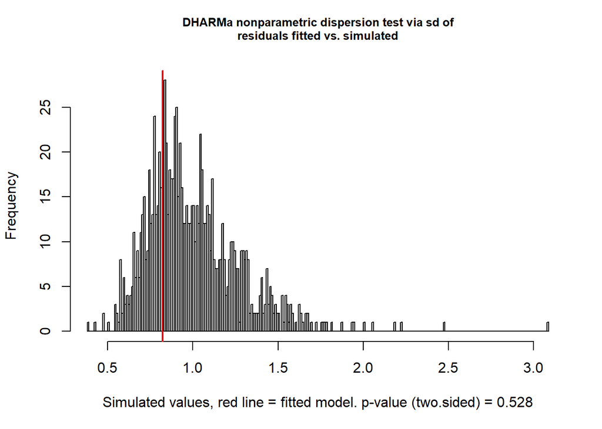

```
##
##  DHARMa nonparametric dispersion test via sd of residuals fitted vs.
##  simulated
##
## data:  simulationOutput
## dispersion = 0.82239, p-value = 0.528
## alternative hypothesis: two.sided
```

```r
simulationOutput <- simulateResiduals(fittedModel = capture_opistoW, n = 1000)
testDispersion(simulationOutput = simulationOutput, alternative ="two.sided")
```

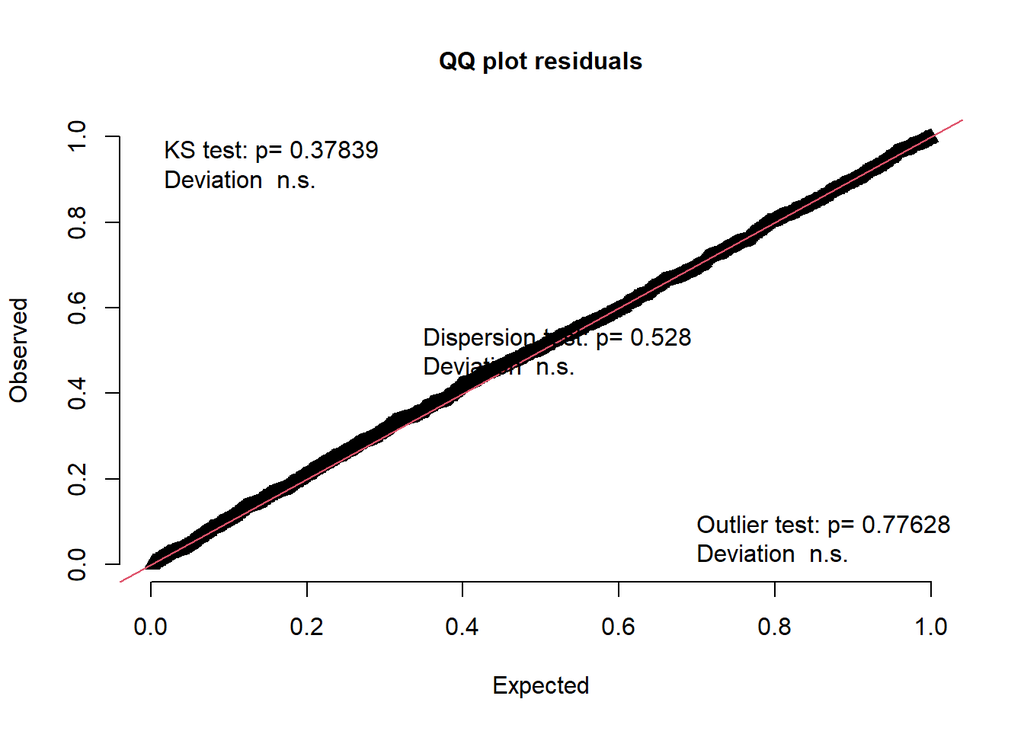

```
##
##  One-sample Kolmogorov-Smirnov test
##
## data:  simulationOutput$scaledResiduals
## D = 0.023038, p-value = 0.3784
## alternative hypothesis: two-sided
```

```r
testUniformity(simulationOutput = simulationOutput, alternative ="two.sided")
```

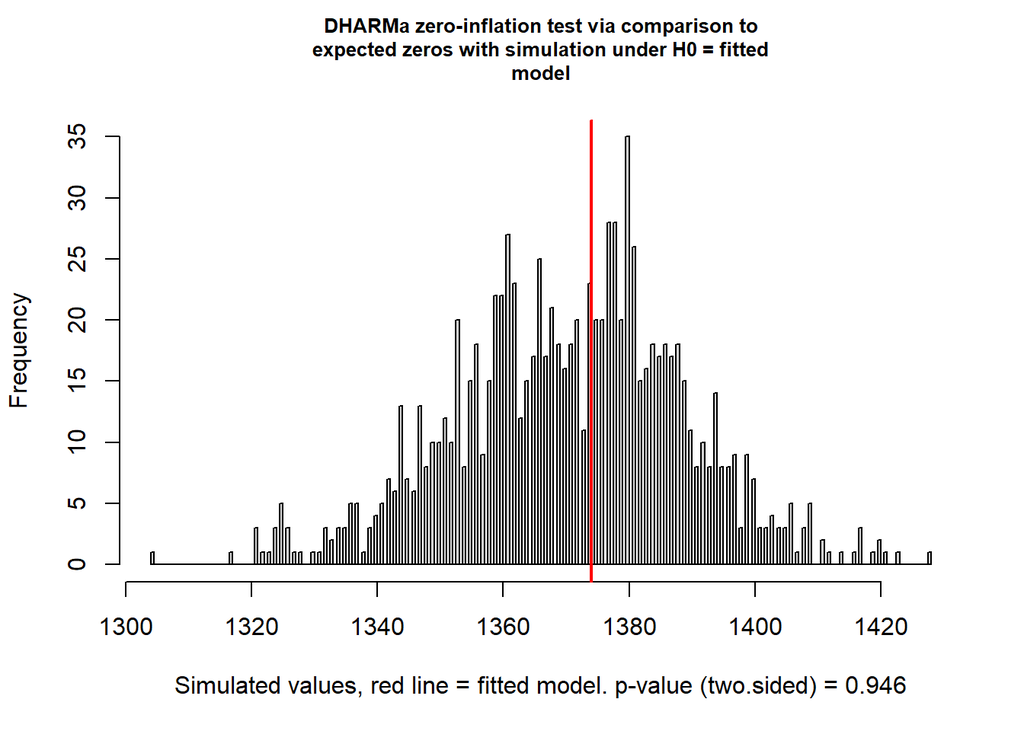

```
##
##  DHARMa zero-inflation test via comparison to expected zeros with
##  simulation under H0 = fitted model
##
## data:  simulationOutput
## ratioObsSim = 1.0024, p-value = 0.946
## alternative hypothesis: two.sided
```

```r
testZeroInflation(simulationOutput = simulationOutput, alternative ="two.sided")
```

*everything seems ok*

Check the significance of the predictor

```r
Anova(capture_opistoW)
```

```
## Analysis of Deviance Table (Type II Wald chisquare tests)
##
## Response: total_preys
##          Chisq Df Pr(>Chisq)
## opisto_w 0.328  1     0.5668
```

*Because width is not related with prey capture, which is the variable we are interested in, we decided to remove it for the subsequent analyses*

**Web area and web height present collinearity**

Run the model

```r
mod_webArea_Heigth<-lm(sqrt(web_area+10)~Web_height,data=unique_ind)
```

Check the assumptions of the linear model

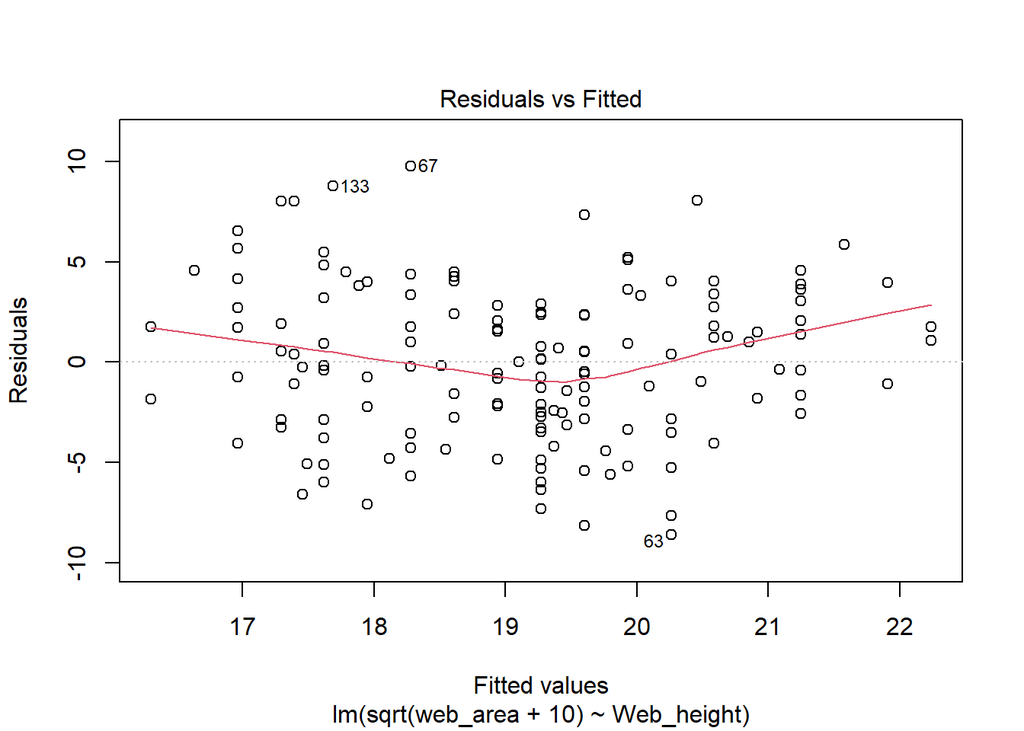

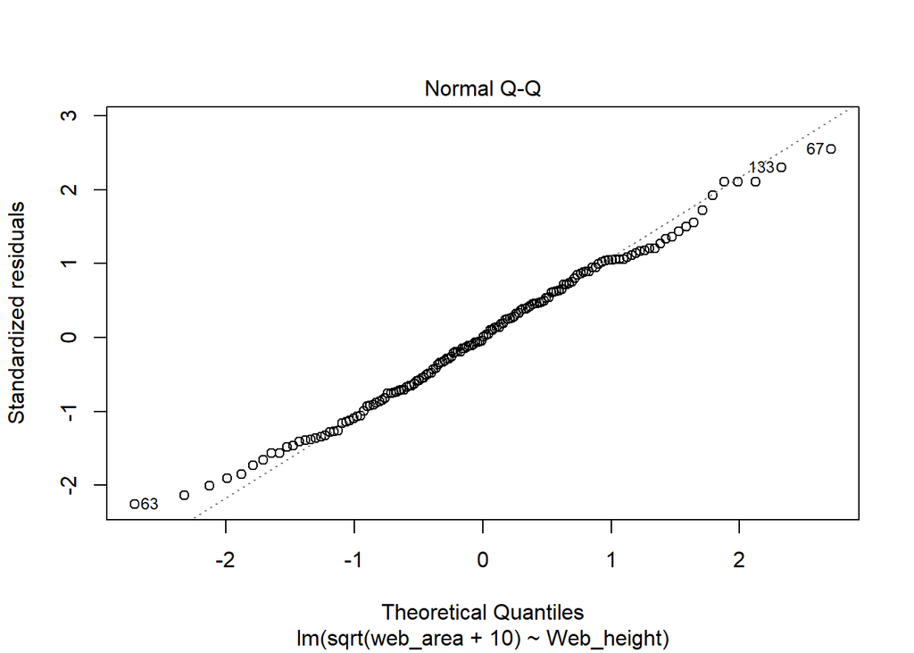

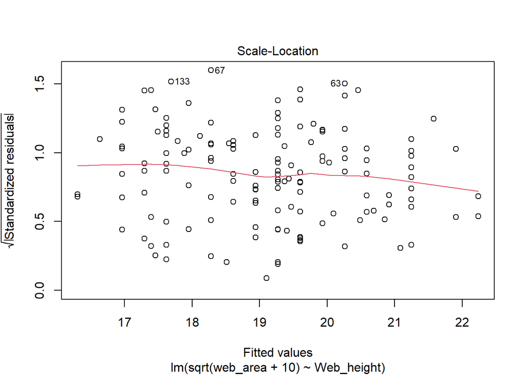

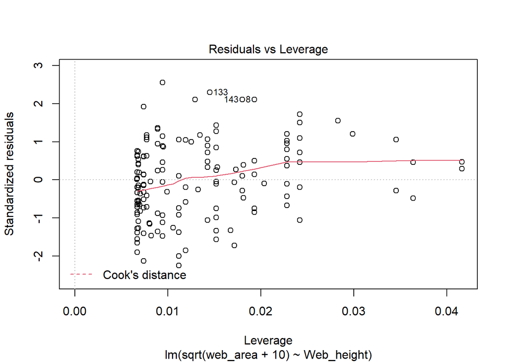

```r
plot(mod_webArea_Heigth)
```

```r
shapiro.test(mod_webArea_Heigth$residuals)
```

```
##
##  Shapiro-Wilk normality test
##
## data:  mod_webArea_Heigth$residuals
## W = 0.99232, p-value = 0.6011
```

*everything seems ok*

Check the significance of the predictor

```r
summary(mod_webArea_Heigth)
```

```
##
## Call:
## lm(formula = sqrt(web_area + 10) ~ Web_height, data = unique_ind)
##
## Residuals:
##     Min      1Q  Median      3Q     Max
## -8.6118 -2.7954 -0.0652  2.7971  9.7547
##
## Coefficients:
##              Estimate Std. Error t value Pr(>|t|)
## (Intercept) 14.982515   1.017724  14.722  < 2e-16 ***
## Web_height   0.032980   0.007664   4.303 3.05e-05 ***
## ---
## Signif. codes:  0 '***' 0.001 '**' 0.01 '*' 0.05 '.' 0.1 ' ' 1
##
## Residual standard error: 3.839 on 148 degrees of freedom
## Multiple R-squared:  0.1112, Adjusted R-squared:  0.1052
## F-statistic: 18.52 on 1 and 148 DF,  p-value: 3.048e-05
```

```r
Anova(mod_webArea_Heigth)
```

```
## Anova Table (Type II tests)
##
## Response: sqrt(web_area + 10)
##             Sum Sq  Df F value    Pr(>F)
## Web_height  272.85   1  18.516 3.048e-05 ***
## Residuals  2180.93 148
## ---
## Signif. codes:  0 '***' 0.001 '**' 0.01 '*' 0.05 '.' 0.1 ' ' 1
```

# Light differences between sides and colour morphs

**Light measures are bimodal, in consequences we decided to this variable as binary (high or low). This categorization can be explore**

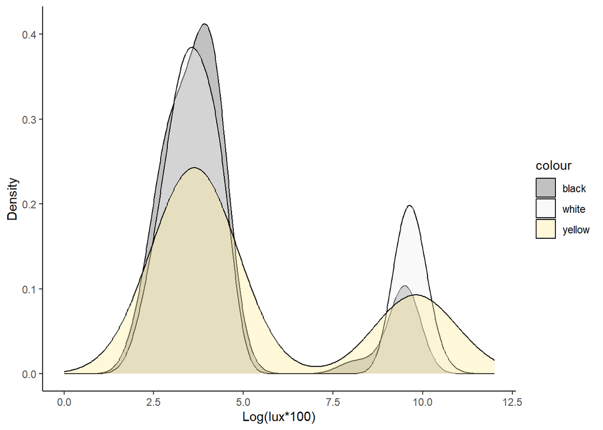

```r
paleta<-c("#636363","#f0f0f0","#ffeda0")

ggplot(data=tmp_noNA, aes(x=log(luxes*100), group=colour, fill=colour)) +
    geom_density(adjust=1.5, alpha=.4) +
    scale_fill_manual(values=paleta)+
    scale_x_continuous(limits=c(0,12))+
    theme_classic()+labs(y="Density",x="Log(lux*100)")
```

**We explore if there were differences between sides in the exposure to a certain light condition**

Run the model

```r
light_side<-glmmTMB(formula=b_luxes ~ Side+ (1|code)+(1|day),family="binomial",data=tmp_ind)
```

Check the significance of the predictor

```r
summary(light_side)
```

```
##  Family: binomial  ( logit )
## Formula:          b_luxes ~ Side + (1 | code) + (1 | day)
## Data: tmp_ind
##
##      AIC      BIC   logLik deviance df.resid
##   1516.6   1538.5   -754.3   1508.6     1774
##
## Random effects:
##
## Conditional model:
##  Groups Name        Variance Std.Dev.
##  code   (Intercept) 3.9175   1.9793
##  day    (Intercept) 0.4532   0.6732
## Number of obs: 1778, groups:  code, 129; day, 6
##
## Conditional model:
##             Estimate Std. Error z value Pr(>|z|)
## (Intercept)  -2.8531     0.3745  -7.618 2.57e-14 ***
## Sideventral   1.5409     0.1504  10.245  < 2e-16 ***
## ---
## Signif. codes:  0 '***' 0.001 '**' 0.01 '*' 0.05 '.' 0.1 ' ' 1
```

```r
Anova(light_side)
```

```
## Analysis of Deviance Table (Type II Wald chisquare tests)
##
## Response: b_luxes
##       Chisq Df Pr(>Chisq)
## Side 104.95  1  < 2.2e-16 ***
## ---
## Signif. codes:  0 '***' 0.001 '**' 0.01 '*' 0.05 '.' 0.1 ' ' 1
```

We found that the ventral side is more often expose to conditions of high luminosity. Let’s visualize the results

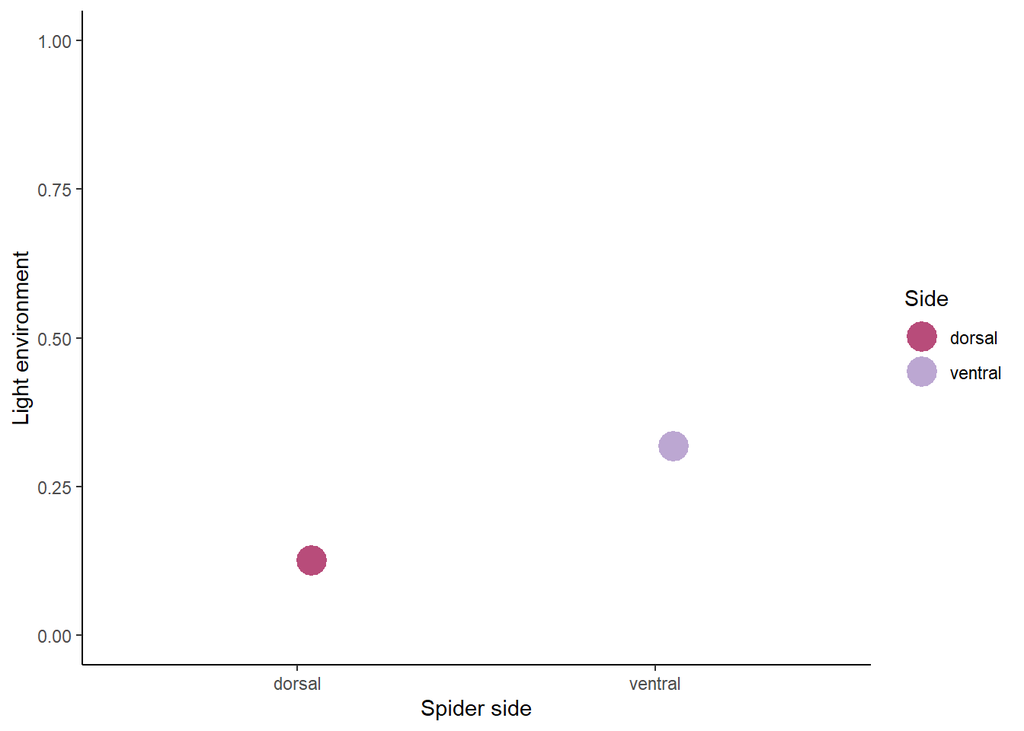

```r
#Predict the values based on the model
tmp_ind$light_side<-predict(light_side,type="response")
#Colours
paleta_side<-c("#B84C7A","#BCA7D2")
#Plot
ggplot(data = tmp_ind,aes(x=Side,y=light_side, fill=Side))+
scale_y_continuous(limits=c(0,1))+
     scale_fill_manual(values=paleta_side)+
     scale_colour_manual(values=paleta_side)+
     stat_summary(fun = mean,aes(color = Side,group=Side),fun.min = function(x) mean(x) - (2*se(x)),fun.max = function(x) mean(x)+(2*se(x)),geom = "pointrange", position = position_jitterdodge(jitter.width=0.15), size=1.5)+
     theme_classic()+labs(x="Spider side",y="Light environment")
```

**We also tested if the colour morphs differ in which side is expose to the different light environments**

Run the model with yellow and ventral as fixed levels

```r
tmp_ind$colour<-relevel(as.factor(tmp_ind$colour),"yellow")
tmp_ind$Side<-relevel(as.factor(tmp_ind$Side),"ventral")
colour_light1<-glmmTMB(formula=b_luxes ~ Side*colour + (1|code) + (1|day) ,family="binomial",data=tmp_ind)
```

Check the significance of the predictor

```r
summary(colour_light1)
```

```
##  Family: binomial  ( logit )
## Formula:          b_luxes ~ Side * colour + (1 | code) + (1 | day)
## Data: tmp_ind
##
##      AIC      BIC   logLik deviance df.resid
##   1485.9   1529.7   -734.9   1469.9     1770
##
## Random effects:
##
## Conditional model:
##  Groups Name        Variance Std.Dev.
##  code   (Intercept) 3.9748   1.994
##  day    (Intercept) 0.4597   0.678
## Number of obs: 1778, groups:  code, 129; day, 6
##
## Conditional model:
##                        Estimate Std. Error z value Pr(>|z|)
## (Intercept)             -0.5977     0.4540  -1.317  0.18800
## Sidedorsal              -2.7857     0.2873  -9.696  < 2e-16 ***
## colourblack             -1.4535     0.6207  -2.342  0.01919 *
## colourwhite             -0.9977     0.4570  -2.183  0.02904 *
## Sidedorsal:colourblack   1.4252     0.4776   2.984  0.00284 **
## Sidedorsal:colourwhite   1.9959     0.3488   5.722 1.05e-08 ***
## ---
## Signif. codes:  0 '***' 0.001 '**' 0.01 '*' 0.05 '.' 0.1 ' ' 1
```

```r
Anova(colour_light1,type=3)
```

```
## Analysis of Deviance Table (Type III Wald chisquare tests)
##
## Response: b_luxes
##               Chisq Df Pr(>Chisq)
## (Intercept)  1.7332  1      0.188
## Side        94.0183  1  < 2.2e-16 ***
## colour       7.1512  2      0.028 *
## Side:colour 32.8057  2  7.522e-08 ***
## ---
## Signif. codes:  0 '***' 0.001 '**' 0.01 '*' 0.05 '.' 0.1 ' ' 1
```

Run the model with black and dorsal as fixed levels

```r
tmp_ind$colour<-relevel(as.factor(tmp_ind$colour),"black")
tmp_ind$Side<-relevel(as.factor(tmp_ind$Side),"dorsal")
colour_light2<-glmmTMB(formula=b_luxes ~ Side*colour + (1|code) + (1|day),
       family="binomial",data=tmp_ind)
```

Check the significance of the predictors

```r
summary(colour_light2)
```

```
##  Family: binomial  ( logit )
## Formula:          b_luxes ~ Side * colour + (1 | code) + (1 | day)
## Data: tmp_ind
##
##      AIC      BIC   logLik deviance df.resid
##   1485.9   1529.7   -734.9   1469.9     1770
##
## Random effects:
##
## Conditional model:
##  Groups Name        Variance Std.Dev.
##  code   (Intercept) 3.9749   1.994
##  day    (Intercept) 0.4597   0.678
## Number of obs: 1778, groups:  code, 129; day, 6
##
## Conditional model:
##                          Estimate Std. Error z value Pr(>|z|)
## (Intercept)              -3.41165    0.63944  -5.335 9.53e-08 ***
## Sideventral               1.36046    0.38597   3.525 0.000424 ***
## colouryellow              0.02826    0.68811   0.041 0.967236
## colourwhite               1.02645    0.63868   1.607 0.108024
## Sideventral:colouryellow  1.42520    0.47755   2.984 0.002841 **
## Sideventral:colourwhite  -0.57068    0.43453  -1.313 0.189072
## ---
## Signif. codes:  0 '***' 0.001 '**' 0.01 '*' 0.05 '.' 0.1 ' ' 1
```

```r
Anova(colour_light2,type=3)
```

```
## Analysis of Deviance Table (Type III Wald chisquare tests)
##
## Response: b_luxes
##               Chisq Df Pr(>Chisq)
## (Intercept) 28.4665  1  9.534e-08 ***
## Side        12.4243  1  0.0004238 ***
## colour       5.1592  2  0.0758037 .
## Side:colour 32.8061  2  7.520e-08 ***
## ---
## Signif. codes:  0 '***' 0.001 '**' 0.01 '*' 0.05 '.' 0.1 ' ' 1
```

Let’s visualize the results

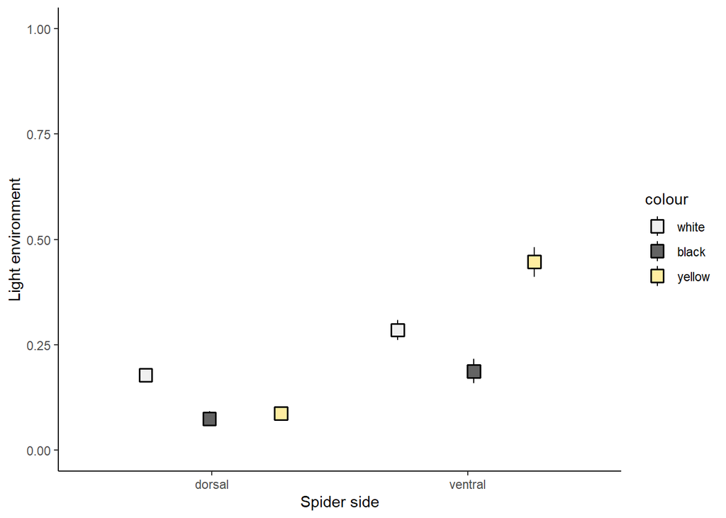

```r
#Predict the values based on the model
tmp_ind$predicted_light<-predict(colour_light1,type="response")
#Colours
tmp_ind$colour<-relevel(as.factor(tmp_ind$colour),"white")
tmp_ind$Side<-relevel(as.factor(tmp_ind$Side),"dorsal")
paleta2<-c("#f0f0f0","#636363","#ffeda0")
#Plot
ggplot(data = tmp_ind,aes(x=Side,y=predicted_light, fill=colour))+
scale_y_continuous(limits=c(0,1))+labs(x="Spider side",y="Light environment")+
     scale_fill_manual(values=paleta2)+
     scale_colour_manual(values=paleta2)+
     stat_summary(fun = mean,aes(color = colour,group=colour),fun.min = function(x) mean(x) - (2*se(x)),fun.max = function(x) mean(x)+(2*se(x)),geom = "pointrange", shape=22,col="black",position = position_jitterdodge(jitter.width=0.15), size=1)+
     theme_classic()
```

## Side filtering and analyses

we compared dorsal and ventral light measures of each individual, where the higher measure was considered as open space and the lower measure as vegetation. We did this for everyday of observation. The following code will create a new dataset.

```r
unique_ind2<-data.frame()
for(d in unique(tmp_ind$day)){
       sub<-tmp_ind %>% filter(day==d & Time==6.3)
       unique_ind2<-rbind(unique_ind2,sub)
}
side_data<-tibble(code=character(),side=character(),open_space=numeric(),day=numeric())
for(d in unique(unique_ind2$day)){
       filtered_day<-unique_ind2 %>% filter(day==d)
       tmp<-tibble(code=character(),side=character(),open_space=numeric(),day=numeric())
       for(ind in unique(filtered_day$code)) {
              dorsal<-filtered_day %>% filter(code==ind & Side=="dorsal")
              ventral<-filtered_day %>% filter(code==ind & Side=="ventral")
              if(nrow(ventral)==0 | nrow(dorsal)==0){next}
              else if(ventral$luxes>dorsal$luxes){
                     ventral<-tibble(code=ind,side="ventral",open_space=1,day=d)
                     dorsal<-tibble(code=ind,side="dorsal",open_space=0,day=d)
                     tmp<-rbind(tmp,ventral,dorsal)
              } else if(ventral$luxes<dorsal$luxes){
                     ventral<-tibble(code=ind,side="ventral",open_space=0,day=d)
                     dorsal<-tibble(code=ind,side="dorsal",open_space=1,day=d)
                     tmp<-rbind(tmp,ventral,dorsal)
              }
       }
side_data<-rbind(side_data,tmp)
}
```

Let’s evaluate if the new categorization is independent of how the spider position its body towards the different light conditions (High or Low luminosity)

```r
test_association<-chisq.test(factor(unique_ind2$t_luxes),factor(unique_ind2$site_exp))
test_association
```

```
##
##  Pearson's Chi-squared test with Yates' continuity correction
##
## data:  factor(unique_ind2$t_luxes) and factor(unique_ind2$site_exp)
## X-squared = 2.1355, df = 1, p-value = 0.1439
```

Because we did not find association, let’s run an independent model

```r
open_side<-glmmTMB(formula=open_space ~ side+ (1|day) + (1|code),family="binomial",data=side_data) #test which side is most
```

Check the model’s fit

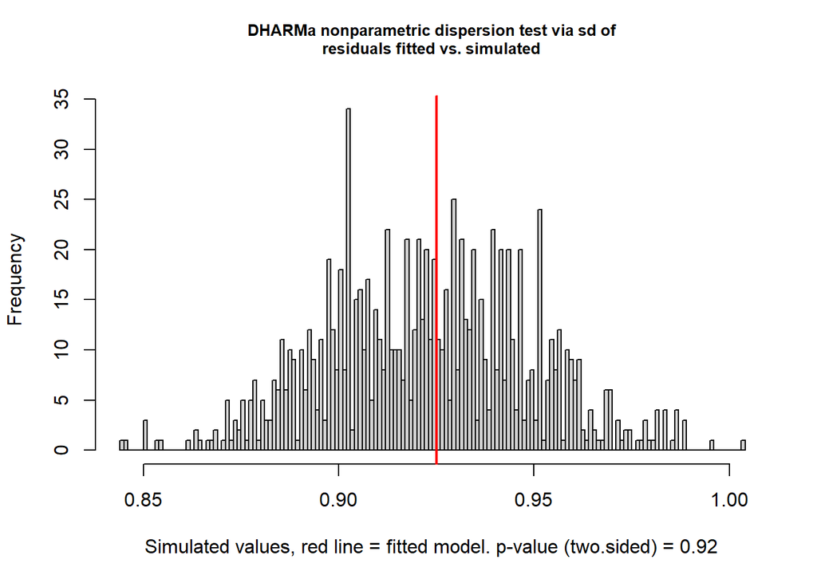

```r
simulationOutput <- simulateResiduals(fittedModel = open_side, n = 1000)
testDispersion(simulationOutput = simulationOutput, alternative ="two.sided")
```

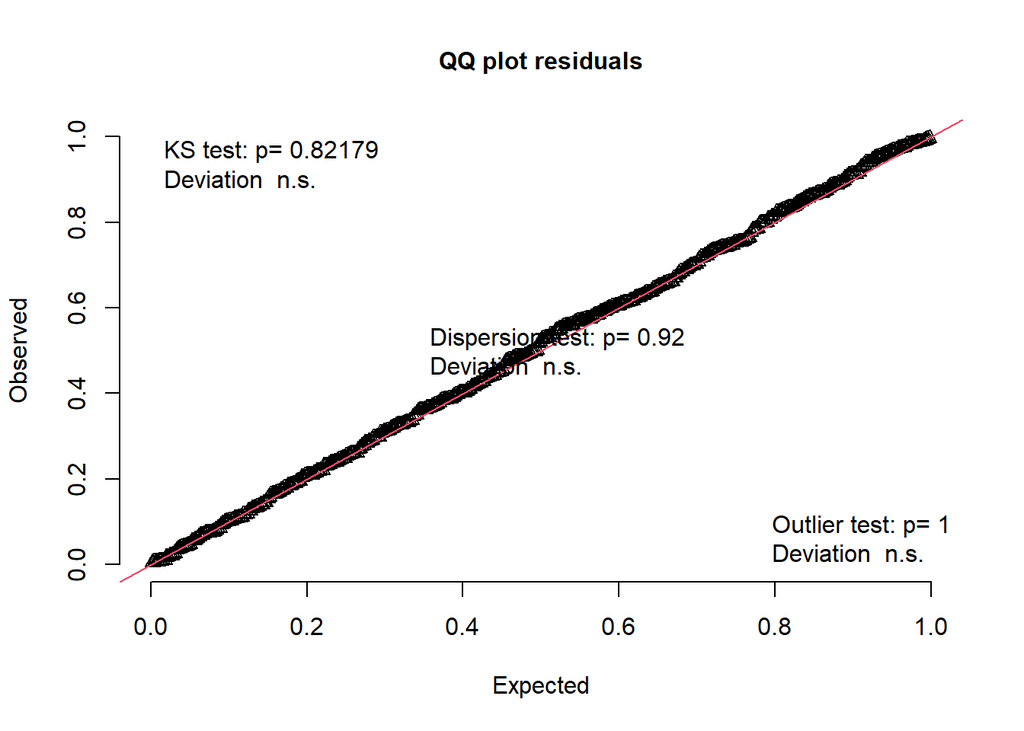

```r
testUniformity(simulationOutput = simulationOutput, alternative ="two.sided")
```

Check the significance of the predictor

```r
summary(open_side)
```

```
##  Family: binomial  ( logit )
## Formula:          open_space ~ side + (1 | day) + (1 | code)
## Data: side_data
##
##      AIC      BIC   logLik deviance df.resid
##    601.9    618.4   -297.0    593.9      450
##
## Random effects:
##
## Conditional model:
##  Groups Name        Variance  Std.Dev.
##  day    (Intercept) 1.099e-11 3.315e-06
##  code   (Intercept) 4.651e-10 2.157e-05
## Number of obs: 454, groups:  day, 6; code, 129
##
## Conditional model:
##             Estimate Std. Error z value Pr(>|z|)
## (Intercept)  -0.5700     0.1382  -4.125 3.70e-05 ***
## sideventral   1.1400     0.1954   5.834 5.41e-09 ***
## ---
## Signif. codes:  0 '***' 0.001 '**' 0.01 '*' 0.05 '.' 0.1 ' ' 1
```

```r
Anova(open_side)
```

```
## Analysis of Deviance Table (Type II Wald chisquare tests)
##
## Response: open_space
##       Chisq Df Pr(>Chisq)
## side 34.038  1  5.406e-09 ***
## ---
## Signif. codes:  0 '***' 0.001 '**' 0.01 '*' 0.05 '.' 0.1 ' ' 1
```

# Capture models

## Effect of the presence of the colour morphs on the web

**We explored the effect of the presence of the presence of the spiders on the web. We also included the presence of silk decorations as a predictor**

```r
tmp_noNA$colour<-relevel(as.factor(tmp_noNA$colour),"empty")
tmp_noNA$Time<-relevel(as.factor(tmp_noNA$Time),"6.3")
with_control_model<-glmmTMB(formula=total_preys ~ colour+sqrt(web_area+10)+presence_decorations + check + (1|code) + (1|day/Time),family="poisson",REML=F,data=tmp_noNA)
```

Check the uniformity, dispersion and zero inflation of the model

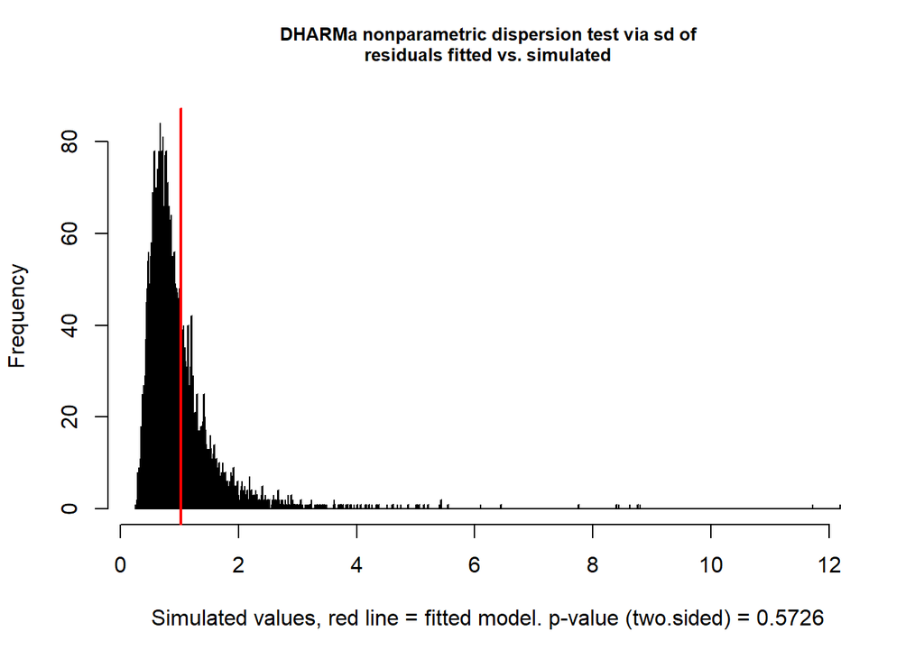

```
##
##  DHARMa nonparametric dispersion test via sd of residuals fitted vs.
##  simulated
##
## data:  simulationOutput
## dispersion = 1.1036, p-value = 0.5726
## alternative hypothesis: two.sided
```

```r
simulationOutput <- simulateResiduals(fittedModel = with_control_model, n = 10000)
testDispersion(simulationOutput = simulationOutput, alternative ="two.sided")
```

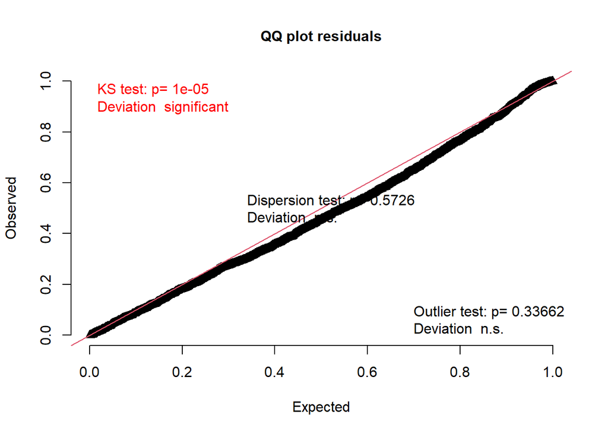

```
##
##  One-sample Kolmogorov-Smirnov test
##
## data:  simulationOutput$scaledResiduals
## D = 0.055171, p-value = 7.514e-06
## alternative hypothesis: two-sided
```

```r
testUniformity(simulationOutput = simulationOutput, alternative ="two.sided")
```

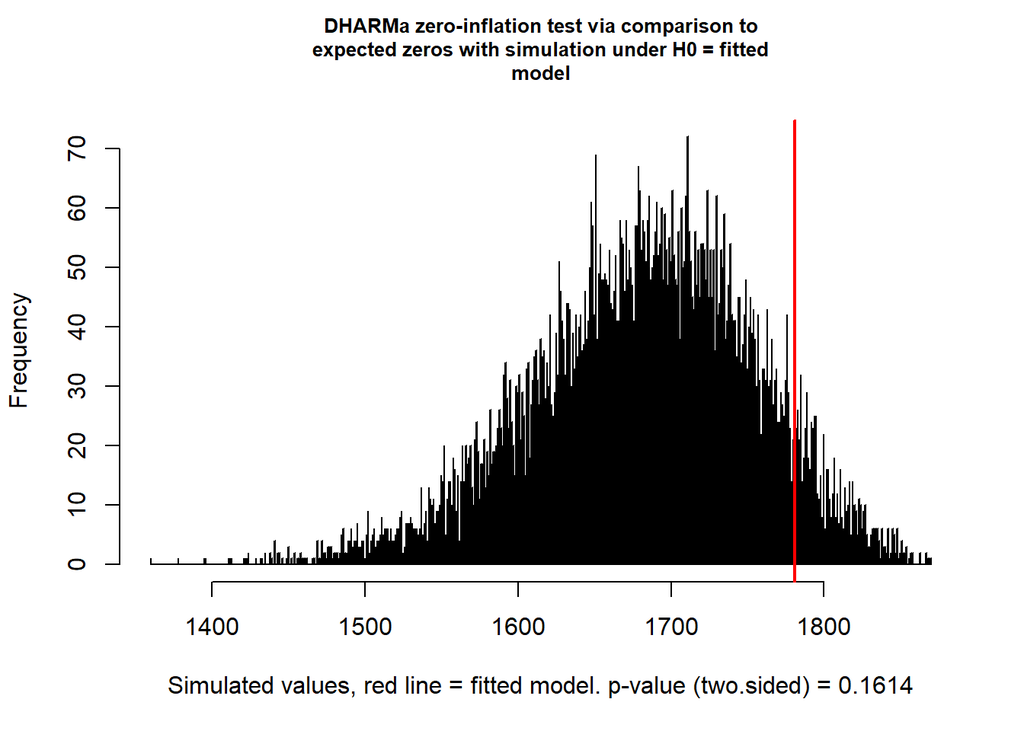

```
##
##  DHARMa zero-inflation test via comparison to expected zeros with
##  simulation under H0 = fitted model
##
## data:  simulationOutput
## ratioObsSim = 1.0595, p-value = 0.1614
## alternative hypothesis: two.sided
```

```r
testZeroInflation(simulationOutput = simulationOutput, alternative ="two.sided")
```

**Because there is not uniformity of the residuals when using a poisson distribution, we run the model again with a negative binomial distribution**

```r
tmp_noNA$colour<-relevel(as.factor(tmp_noNA$colour),"empty")
tmp_noNA$Time<-relevel(as.factor(tmp_noNA$Time),"6.3")
with_control_model<-glmmTMB(formula=total_preys ~ colour+sqrt(web_area+10)+presence_decorations + check + (1|code) + (1|day/Time),family="nbinom2",REML=F,data=tmp_noNA)
```

Check the uniformity, dispersion and zero inflation of the model

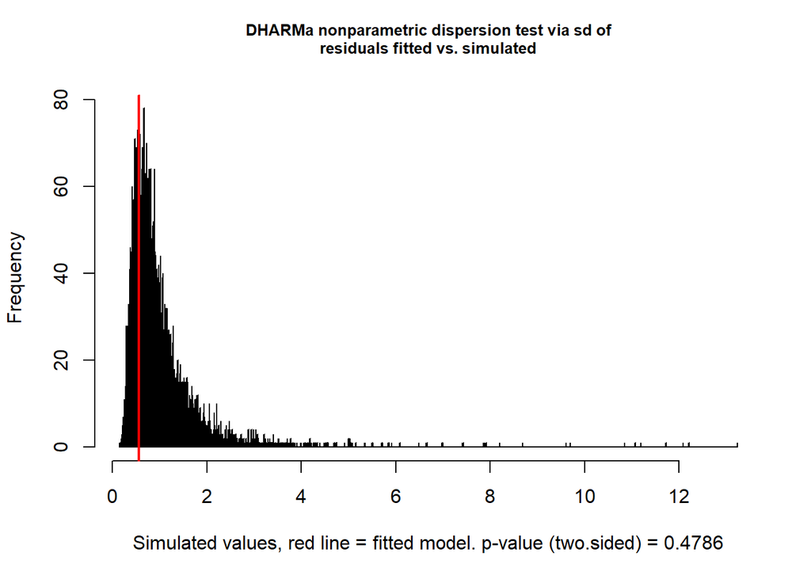

```
##
##  DHARMa nonparametric dispersion test via sd of residuals fitted vs.
##  simulated
##
## data:  simulationOutput
## dispersion = 0.57703, p-value = 0.4786
## alternative hypothesis: two.sided
```

```r
simulationOutput <- simulateResiduals(fittedModel = with_control_model, n = 10000)
testDispersion(simulationOutput = simulationOutput, alternative ="two.sided")
```

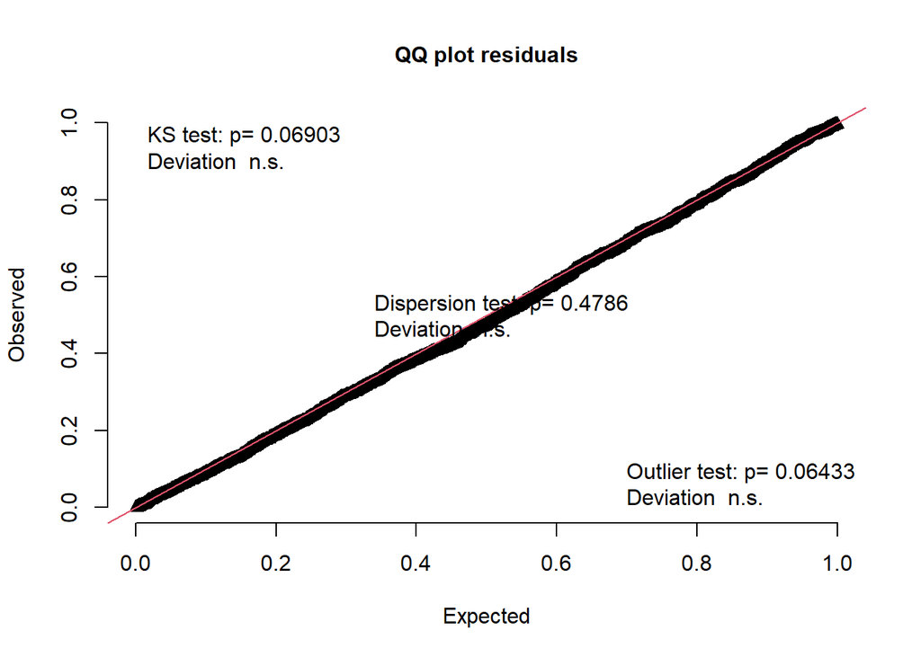

```
##
##  One-sample Kolmogorov-Smirnov test
##
## data:  simulationOutput$scaledResiduals
## D = 0.02864, p-value = 0.06903
## alternative hypothesis: two-sided
```

```r
testUniformity(simulationOutput = simulationOutput, alternative ="two.sided")
```

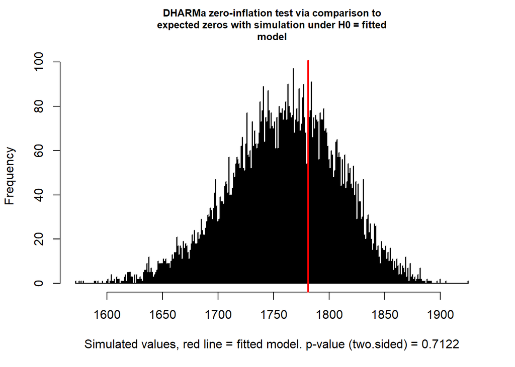

```
##
##  DHARMa zero-inflation test via comparison to expected zeros with
##  simulation under H0 = fitted model
##
## data:  simulationOutput
## ratioObsSim = 1.0122, p-value = 0.7122
## alternative hypothesis: two.sided
```

```r
testZeroInflation(simulationOutput = simulationOutput, alternative ="two.sided")
```

*everything seems ok*

Check the significance of the predictors

```r
summary(with_control_model)
```

```
##  Family: nbinom2  ( log )
## Formula:
## total_preys ~ colour + sqrt(web_area + 10) + presence_decorations +
##     check + (1 | code) + (1 | day/Time)
## Data: tmp_noNA
##
##      AIC      BIC   logLik deviance df.resid
##   2135.1   2202.6  -1055.6   2111.1     2040
##
## Random effects:
##
## Conditional model:
##  Groups   Name        Variance Std.Dev.
##  code     (Intercept) 0.1192   0.3452
##  Time:day (Intercept) 0.1922   0.4384
##  day      (Intercept) 0.2696   0.5193
## Number of obs: 2052, groups:  code, 150; Time:day, 23; day, 6
##
## Dispersion parameter for nbinom2 family (): 0.339
##
## Conditional model:
##                         Estimate Std. Error z value Pr(>|z|)
## (Intercept)             -1.45213    0.48582  -2.989   0.0028 **
## colourblack             -1.19340    0.26087  -4.575 4.77e-06 ***
## colourwhite             -1.11115    0.21595  -5.145 2.67e-07 ***
## colouryellow            -1.18243    0.22258  -5.312 1.08e-07 ***
## sqrt(web_area + 10)      0.03853    0.01995   1.931   0.0534 .
## presence_decorationsyes -0.10909    0.16922  -0.645   0.5192
## checkF                   0.00459    0.19537   0.023   0.9813
## checkM                  -0.18729    0.18275  -1.025   0.3054
## ---
## Signif. codes:  0 '***' 0.001 '**' 0.01 '*' 0.05 '.' 0.1 ' ' 1
```

```r
Anova(with_control_model)
```

```
## Analysis of Deviance Table (Type II Wald chisquare tests)
##
## Response: total_preys
##                        Chisq Df Pr(>Chisq)
## colour               36.9717  3  4.665e-08 ***
## sqrt(web_area + 10)   3.7301  1    0.05344 .
## presence_decorations  0.4155  1    0.51917
## check                 1.4183  2    0.49207
## ---
## Signif. codes:  0 '***' 0.001 '**' 0.01 '*' 0.05 '.' 0.1 ' ' 1
```

*the presence of any of the colour morphs on the web seems to reduce the capture of prey*

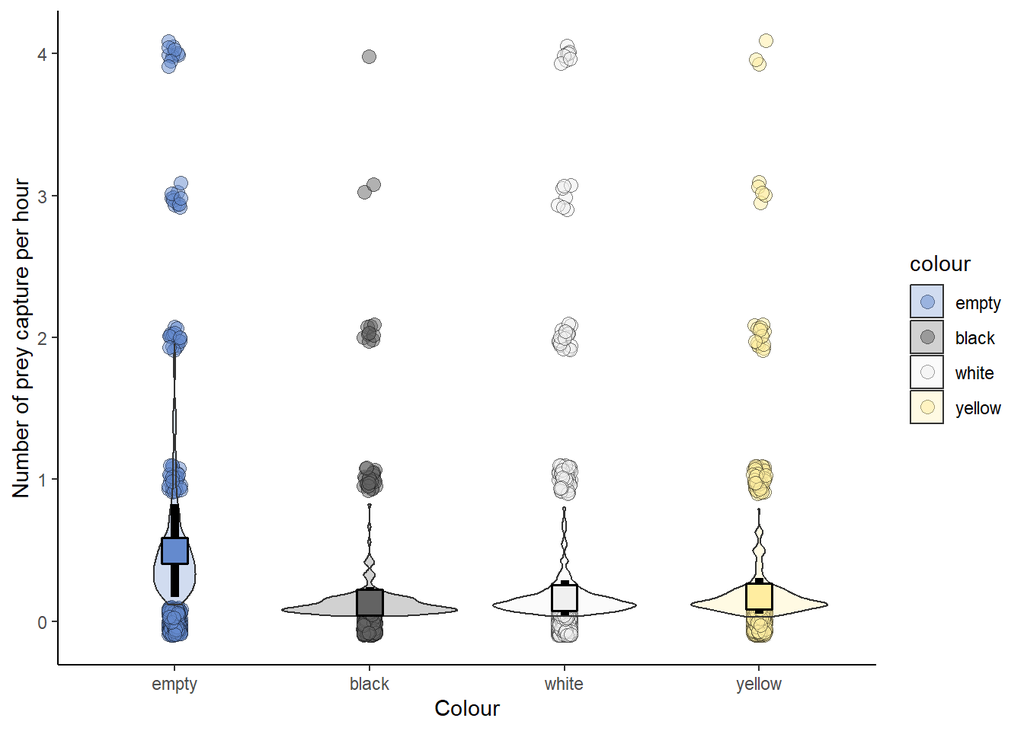

```r
paleta2<-c("#648ace","#636363","#f0f0f0","#ffeda0")
#pdf("dorsal.pdf",height=8,width=10)
tmp_noNA$total_response<-predict(with_control_model,type="response")
ggplot(data = tmp_noNA,aes(x=colour,y=total_response))+
  geom_point(data = tmp_noNA,aes(x=colour,y=total_preys, fill=colour),shape = 21,size=3, position = position_jitterdodge(jitter.width=0.2,jitter.height=0.1),alpha=0.5)+
  scale_fill_manual(values=paleta2)+
  geom_violin(aes(x=colour,y=total_response,fill=colour),alpha=0.3,size=0.4)+scale_color_manual(values=paleta2)+
  stat_summary(fun = mean,aes(group=colour,col=colour),fun.min = function(x) mean(x) - sd(x),fun.max = function(x) mean(x)+sd(x),geom = "pointrange",linewidth = 2,size=1.5,shape=22,col="black",fill=paleta2)+
theme_classic()+labs(x="Colour",y="Number of prey capture per hour")
```

## Explore the differences on prey capture considering side and colour morph

Run the model with white and ventral as fixed levels

```r
tmp_ind$colour<-relevel(as.factor(tmp_ind$colour),"white")
tmp_ind$Side<-relevel(as.factor(tmp_ind$Side),"ventral")
tmp_ind$Time<-relevel(as.factor(tmp_ind$Time),"6.3")
total_model_poisson<-glmmTMB::glmmTMB(formula=total_preys ~ Side+colour+t_luxes+sqrt(web_area+10)+ check + (1|code) + (1|day/Time),family="poisson",REML=F,data=tmp_ind)
```

### Poisson model

```r
total_model_poisson<-glmmTMB::glmmTMB(formula=total_preys ~ Side+colour+t_luxes+sqrt(web_area+10)+ check + (1|code) + (1|day/Time),family="poisson",REML=F,data=tmp_ind)
```

Test the fit of the model and zero inflation

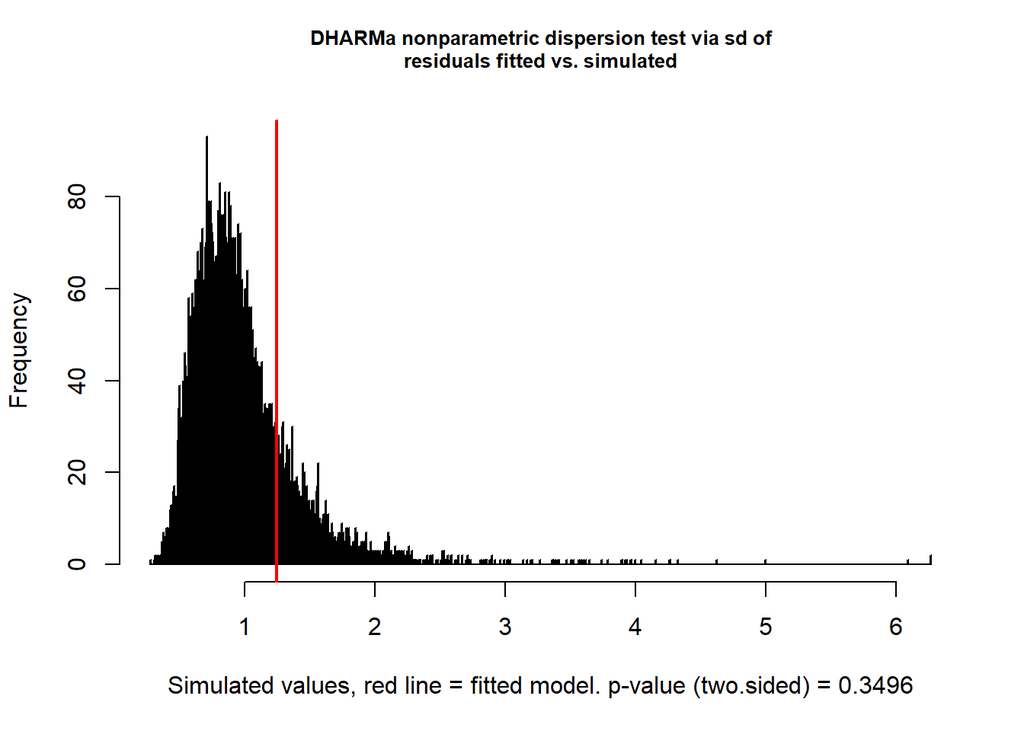

```
##
##  DHARMa nonparametric dispersion test via sd of residuals fitted vs.
##  simulated
##
## data:  simulationOutput
## dispersion = 1.2804, p-value = 0.3496
## alternative hypothesis: two.sided
```

```r
simulationOutput <- simulateResiduals(fittedModel = total_model_poisson, n = 10000)
testDispersion(simulationOutput = simulationOutput, alternative ="two.sided")
```

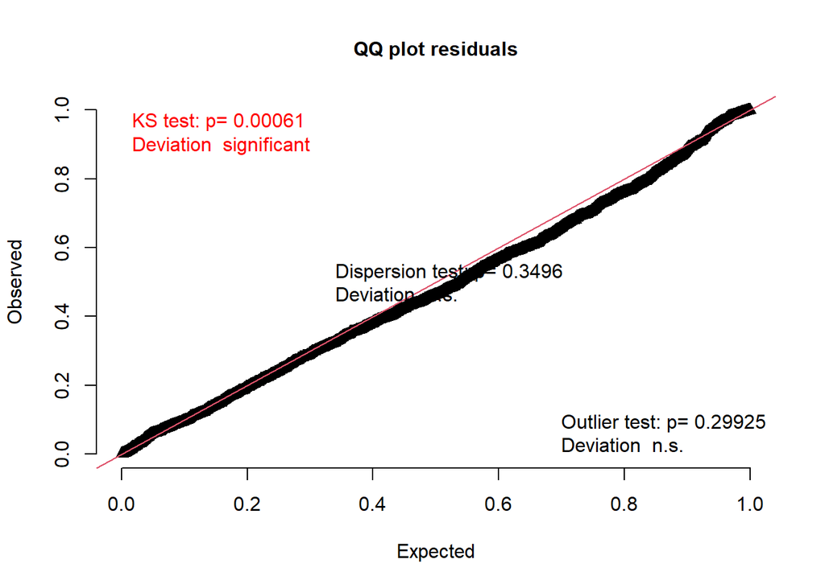

```
##
##  One-sample Kolmogorov-Smirnov test
##
## data:  simulationOutput$scaledResiduals
## D = 0.047735, p-value = 0.0006053
## alternative hypothesis: two-sided
```

```r
testUniformity(simulationOutput = simulationOutput, alternative ="two.sided")
```

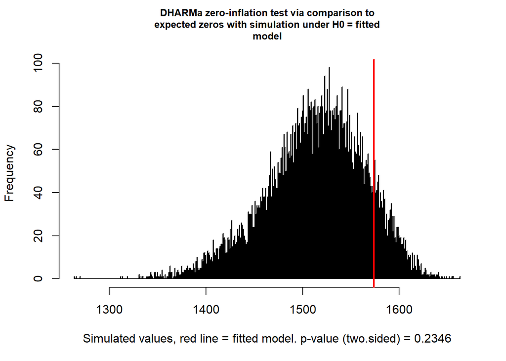

```
##
##  DHARMa zero-inflation test via comparison to expected zeros with
##  simulation under H0 = fitted model
##
## data:  simulationOutput
## ratioObsSim = 1.04, p-value = 0.2346
## alternative hypothesis: two.sided
```

```r
testZeroInflation(simulationOutput = simulationOutput, alternative ="two.sided")
```

**Because this model has no uniformity; its is necessary to try other model that takes this into account**